# ‘Avocado Price’ Analysis

Team Algoritma

August 06, 2021

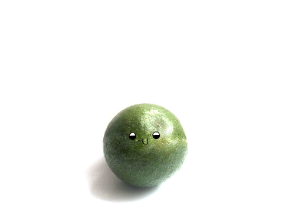

# 1 Studi Kasus

Para millenials di US sangat menyukai avocado toast[^1]. Dikarenakan sangat suka dengan avocado, mereka rela membeli avocado dengan harga yang sangat beragam. Jika kita berperan sebagai konsumen yang ingin membeli avocado, dimana kita harus membeli avocado dengan **harga ekonomis dan kualitas baik**?

```r
# read data avo
avo <- read.csv("data_input/avocado.csv")
head(avo)
```

|  | X | Date | AveragePrice | Total.Volume | X4046 | X4225 | X4770 | Total.Bags | Small.Bags | Large.Bags | XLarge.Bags | type | year | region |
| --- | --- | --- | --- | --- | --- | --- | --- | --- | --- | --- | --- | --- | --- | --- |
| 1 | 0 | 2015-12-27 | 1.33 | 64236.62 | 1036.74 | 54454.85 | 48.16 | 8696.87 | 8603.62 | 93.25 | 0 | conventional | 2015 | Albany |
| 2 | 1 | 2015-12-20 | 1.35 | 54876.98 | 674.28 | 44638.81 | 58.33 | 9505.56 | 9408.07 | 97.49 | 0 | conventional | 2015 | Albany |
| 3 | 2 | 2015-12-13 | 0.93 | 118220.22 | 794.70 | 109149.67 | 130.50 | 8145.35 | 8042.21 | 103.14 | 0 | conventional | 2015 | Albany |
| 4 | 3 | 2015-12-06 | 1.08 | 78992.15 | 1132.00 | 71976.41 | 72.58 | 5811.16 | 5677.40 | 133.76 | 0 | conventional | 2015 | Albany |
| 5 | 4 | 2015-11-29 | 1.28 | 51039.60 | 941.48 | 43838.39 | 75.78 | 6183.95 | 5986.26 | 197.69 | 0 | conventional | 2015 | Albany |
| 6 | 5 | 2015-11-22 | 1.26 | 55979.78 | 1184.27 | 48067.99 | 43.61 | 6683.91 | 6556.47 | 127.44 | 0 | conventional | 2015 | Albany |

Deskripsi data:

- `X` : index data
- `Date` : tanggal observasi
- `AveragePrice` : rata-rata harga satuan avocado
- `Total.Volume` : jumlah seluruh avocado yang terjual
- `X4046` : banyaknya avocado dengan jenis PLU 4046 terjual
- `X4225` : banyaknya avocado dengan jenis PLU 4225 terjual
- `X4770` : banyaknya avocado dengan jenis PLU 4770 terjual
- `Total.Bags` : banyaknya avocado yang terjual pada tas ukuran kecil, besar, dan ekstra besar
- `Small.Bags` : banyaknya avocado yang terjual pada tas ukuran kecil
- `Large.Bags` : banyaknya avocado yang terjual pada tas ukuran besar
- `XLarge.Bags` : banyaknya avocado yang terjual pada tas ukuran ekstra besar
- `type` : jenis avocado, konvensional atau organik
- `year` : tahun
- `region` : kota tempat observasi

## 1.1 Library Used

```r
# untuk data wrangling
library(dplyr)
library(lubridate)

# untuk visualisasi
library(ggplot2)
library(scales)
library(ggthemes)
```

# 2 Exploratory Data Analysis

Fungsi dari ekplorasi data analisis ini adalah untuk lebih mengenal dan mengetahui data yang kita miliki seperti apa. Ekplorasi data ini juga dapat membantu untuk menemukan insight pada suatu data.

## 2.1 Cleansing Data

Pertama, kita akan coba cek pada data `avo` terdapat *missing value* atau tidak. Ternyata data `avo` tidak memiliki *missing value* sama sekali.

```r
# check missing value
colSums(is.na(avo))
```

```
#>            X         Date AveragePrice Total.Volume        X4046        X4225
#>            0            0            0            0            0            0
#>        X4770   Total.Bags   Small.Bags   Large.Bags  XLarge.Bags         type
#>            0            0            0            0            0            0
#>         year       region
#>            0            0
```

```r
# check structure
glimpse(avo)
```

```
#> Rows: 18,249
#> Columns: 14
#> $ X            <int> 0, 1, 2, 3, 4, 5, 6, 7, 8, 9, 10, 11, 12, 13, 14, 15, 16,~
#> $ Date         <chr> "2015-12-27", "2015-12-20", "2015-12-13", "2015-12-06", "~
#> $ AveragePrice <dbl> 1.33, 1.35, 0.93, 1.08, 1.28, 1.26, 0.99, 0.98, 1.02, 1.0~
#> $ Total.Volume <dbl> 64236.62, 54876.98, 118220.22, 78992.15, 51039.60, 55979.~
#> $ X4046        <dbl> 1036.74, 674.28, 794.70, 1132.00, 941.48, 1184.27, 1368.9~
#> $ X4225        <dbl> 54454.85, 44638.81, 109149.67, 71976.41, 43838.39, 48067.~
#> $ X4770        <dbl> 48.16, 58.33, 130.50, 72.58, 75.78, 43.61, 93.26, 80.00, ~
#> $ Total.Bags   <dbl> 8696.87, 9505.56, 8145.35, 5811.16, 6183.95, 6683.91, 831~
#> $ Small.Bags   <dbl> 8603.62, 9408.07, 8042.21, 5677.40, 5986.26, 6556.47, 819~
#> $ Large.Bags   <dbl> 93.25, 97.49, 103.14, 133.76, 197.69, 127.44, 122.05, 562~
#> $ XLarge.Bags  <dbl> 0.00, 0.00, 0.00, 0.00, 0.00, 0.00, 0.00, 0.00, 0.00, 0.0~
#> $ type         <chr> "conventional", "conventional", "conventional", "conventi~
#> $ year         <int> 2015, 2015, 2015, 2015, 2015, 2015, 2015, 2015, 2015, 201~
#> $ region       <chr> "Albany", "Albany", "Albany", "Albany", "Albany", "Albany~
```

Tahap selanjutnya kita ingin coba bersihkan datanya dengan beberapa step tahapan yaitu sebagai berikut :

- mengganti format seluruh nama kolom menjadi huruf kecil
- menyesuaikan tipe data pada kolom yang belum sesuai
- membuang kolom yang tidak diperlukan

```r
# wrangling
avo <- avo %>%
      rename_all(tolower) %>%
      mutate(date = ymd(date)) %>%
      select(-x)
head(avo)
```

|  | date | averageprice | total.volume | x4046 | x4225 | x4770 | total.bags | small.bags | large.bags | xlarge.bags | type | year | region |
| --- | --- | --- | --- | --- | --- | --- | --- | --- | --- | --- | --- | --- | --- |
| 1 | 2015-12-27 | 1.33 | 64236.62 | 1036.74 | 54454.85 | 48.16 | 8696.87 | 8603.62 | 93.25 | 0 | conventional | 2015 | Albany |
| 2 | 2015-12-20 | 1.35 | 54876.98 | 674.28 | 44638.81 | 58.33 | 9505.56 | 9408.07 | 97.49 | 0 | conventional | 2015 | Albany |
| 3 | 2015-12-13 | 0.93 | 118220.22 | 794.70 | 109149.67 | 130.50 | 8145.35 | 8042.21 | 103.14 | 0 | conventional | 2015 | Albany |
| 4 | 2015-12-06 | 1.08 | 78992.15 | 1132.00 | 71976.41 | 72.58 | 5811.16 | 5677.40 | 133.76 | 0 | conventional | 2015 | Albany |
| 5 | 2015-11-29 | 1.28 | 51039.60 | 941.48 | 43838.39 | 75.78 | 6183.95 | 5986.26 | 197.69 | 0 | conventional | 2015 | Albany |
| 6 | 2015-11-22 | 1.26 | 55979.78 | 1184.27 | 48067.99 | 43.61 | 6683.91 | 6556.47 | 127.44 | 0 | conventional | 2015 | Albany |

## 2.2 Visualization

Permasalahan utama yang kita miliki adalah **harga**. Harga selalu terlihat penting saat kita menyukai suatu barang dan ingin membelinya terus menerus. Tentunya sebagai konsumen, kita ingin mendapatkan kualitas barang yang baik namun dengan harga yang ekonomis juga. Oleh karena itu, mari kita perhatikan distribusi dari harga avocado.

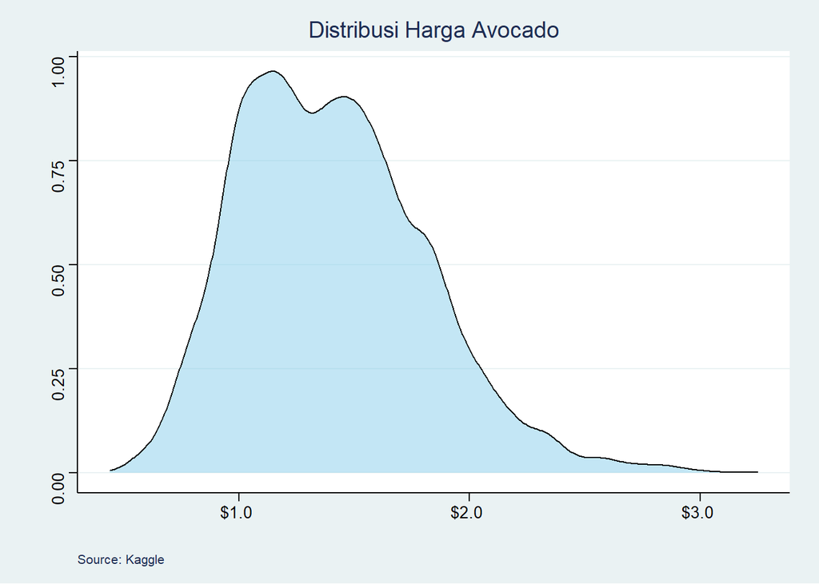

```r
# distribution of averageprice avocado
avo %>%
  ggplot(aes(x = averageprice))+
  geom_density(alpha = 0.5, fill = "skyblue")+
  ggtitle("Distribusi Harga Avocado")+
  labs(caption = "Source: Kaggle", x ="", y ="")+
  scale_x_continuous(labels = unit_format(prefix = "$",
                                          unit = "",
                                          scale = 1))+
  theme_stata()
```

Jika kita perhatikan dari diagram distribusi harga tersebut, kita melihat variasi harga pada avocado yang dijual. Avocado dengan kisaran harga `$1 - $1.5` sangat mudah ditemukan. Namun dengan harga demikian, tipe avocado seperti apakah yang kita peroleh?

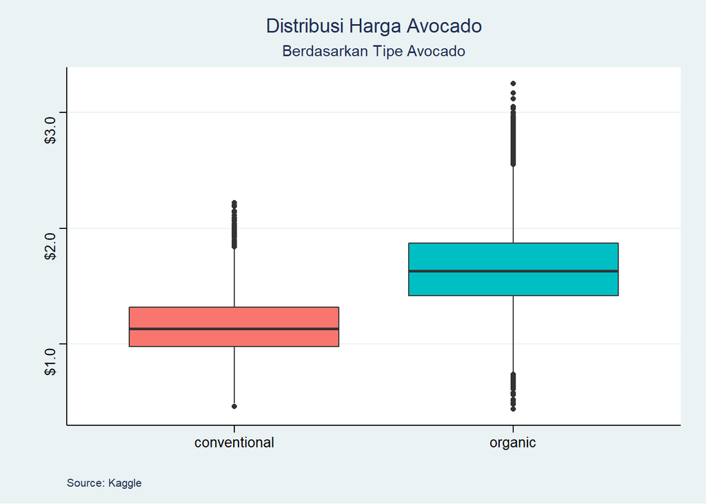

```r
# distribution of avocado price in each type
avo %>%
  ggplot(aes(x = type, y = averageprice))+
  geom_boxplot(aes(fill = type), show.legend = F)+
  ggtitle("Distribusi Harga Avocado",
          subtitle = "Berdasarkan Tipe Avocado")+
  labs(caption = "Source: Kaggle", x ="", y ="")+
  scale_y_continuous(labels = unit_format(prefix = "$",
                                          unit = "",
                                          scale = 1))+
  theme_stata()
```

Menarik sekali, dengan kisaran harga `$1 - $1.5` kita bahkan sudah bisa mendapatkan avocado organik.

Pertanyaan selanjutnya adalah, dimana kita bisa membeli avocado dengan kisaran harga tersebut dan dengan kualitas yang baik dalam hal ini kita ingin mendapatkan avocado organik.

```r
# find top 10 region sell organic avocado with low price
agg_ao <- avo %>%
  filter(type == "organic") %>%
  group_by(region) %>%
  summarise( meanprice = mean(averageprice)) %>%
  ungroup %>%
  arrange(meanprice) %>%
  head(10)

top10_region <- agg_ao %>%
                pull(region)

agg_ao2 <- avo %>%
  filter(type == "organic" &
         region %in% top10_region) %>%
  group_by(region, year) %>%
  summarise( meanprice = mean(averageprice)) %>%
  ungroup %>%
  arrange(meanprice)
```

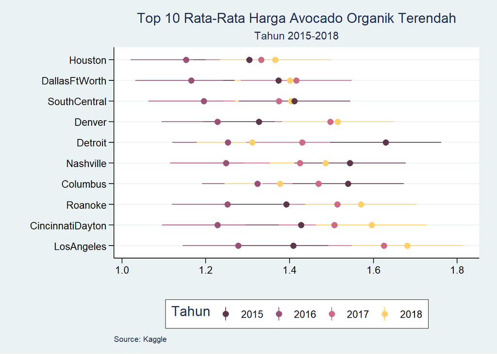

```r
# visualize
agg_ao2 %>%
  ggplot(aes(x = meanprice,
             y = reorder(region, desc(meanprice)),
         xmin = meanprice-sd(meanprice),
         xmax = meanprice+sd(meanprice)))+
  geom_pointrange(aes(color = as.factor(year)))+
  scale_color_manual(values = colorsPuYe,
                     guide_legend(title = "Tahun"))+
  ggtitle("Top 10 Rata-Rata Harga Avocado Organik Terendah",
          subtitle = "Tahun 2015-2018")+
  labs( y = "", x = "", caption = "Source: Kaggle")+
  theme_stata()+
  theme(axis.text.y = element_text(angle = 0))
```

Pada tahun 2018 harga avocado organik yang memiliki nilai paling rendah berasal dari Detroit dengan rata-rata harga `$1.31`. Wilayah Houston memiliki kecenderungan harga avocado organik lebih murah dibandingkan wilayah lainnya di setiap tahun.

Namun, bagaimana jika kita ingin membeli avocado konvensional? Dimana kah kita harus membeli dengan harga yang rendah?

```r
# find top 10 region sell conventional avocado with low price
agg_conv <- avo %>%
  filter(type == "conventional") %>%
  group_by(region) %>%
  summarise( meanprice = mean(averageprice)) %>%
  ungroup %>%
  arrange(meanprice) %>%
  head(10)

top10_region_conv <- agg_conv %>%
                pull(region)

agg_conv2 <- avo %>%
  filter(type == "conventional" &
         region %in% top10_region_conv) %>%
  group_by(region, year) %>%
  summarise( meanprice = mean(averageprice)) %>%
  ungroup %>%
  arrange(meanprice)
```

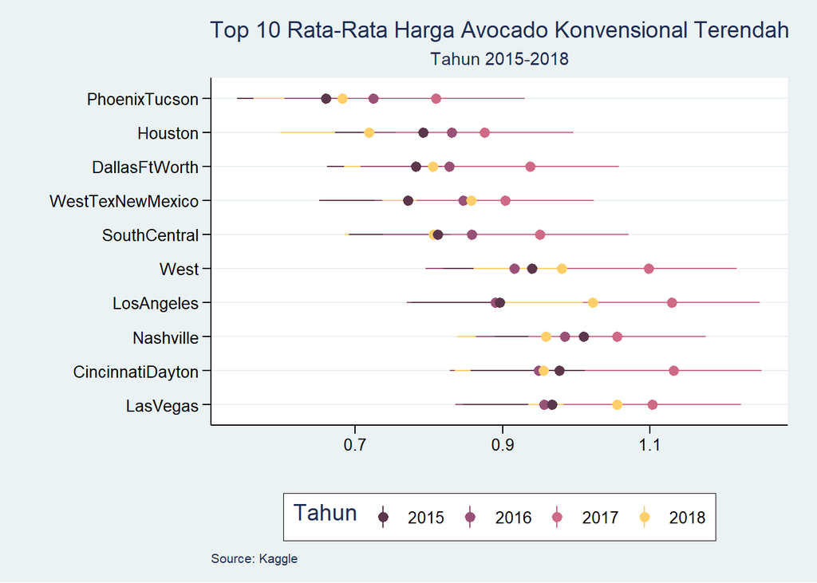

```r
# visualize
agg_conv2 %>%
  ggplot(aes(x = meanprice,
             y = reorder(region, desc(meanprice)),
         xmin = meanprice-sd(meanprice),
         xmax = meanprice+sd(meanprice)))+
  geom_pointrange(aes(color = as.factor(year)))+
  scale_color_manual(values = colorsPuYe,
                     guide_legend(title = "Tahun"))+
  ggtitle("Top 10 Rata-Rata Harga Avocado Konvensional Terendah",
          subtitle = "Tahun 2015-2018")+
  labs( y = "", x = "", caption = "Source: Kaggle")+
  theme_stata()+
  theme(axis.text.y = element_text(angle = 0))
```

Dari hasil visualisasi tersebut kita mendapatkan informasi bahwa harga avocado konvensional rata-rata harga terendah dapat kita temui di wilayah PhoenixTucson.

# 3 Kesimpulan

Hal yang dapat kita simpulkan adalah ketika kita berlaku sebagai konsumen dan kita ingin mendapatkan avocado dengan harga yang rendah, kita memiliki dua pilihan, yaitu organik atau konvensional. Tentunya apabila kita memperhatikan kualitas, kita akan memilih avocado organik dan kita dapat membelinya di Houston. Namun jika kita lebih suka jenis avocado konvensional, kita dapat membeli avocado dengan harga yang rendah di PhoenixTucson.

Ekplorasi data sangatlah penting disini. Melakukan ekplorasi data kita dapat mendapatkan informasi dimana kita akan membeli avocado dengan harga yang ekonomis namun dengan kualitas yang baik pula.

# 4 Reference

[^1]: [Avocado Price](https://www.kaggle.com/neuromusic/avocado-prices)